# Biostat 203B Homework 4

Valentina Arputhasamy

3/18/2021

Load database libraries and the tidyverse frontend:

```r
library(tidyverse)
library(lubridate)
library(miceRanger)
library(glmnet)
```

## Q1. Missing data

Through the Shiny app developed in HW3, we observe abundant missing values in the MIMIC-IV ICU cohort we created. In this question, we use multiple imputation to obtain a data set without missing values.

0. Read following tutorials on the R package miceRanger for imputation: https://github.com/farrellday/miceRanger, https://cran.r-project.org/web/packages/miceRanger/vignettes/miceAlgorithm.html.

   A more thorough book treatment of the practical imputation strategies is the book [*Flexible Imputation of Missing Data*](https://stefvanbuuren.name/fimd/) by Stef van Buuren.
1. Explain the jargon MCAR, MAR, and MNAR.
- MCAR: If the probability of being missing is the same for all cases, then the data are said to be missing completely at random. This implies that causes of the missing data are unrelated to the data. An example of MCAR is a weighing scale that ran out of batteries. Some of the data will be missing simply because of bad luck.
- MAR: If the probability of being missing is the same only within groups defined by the observed data, then the data are missing at random (MAR). MAR is a much broader class than MCAR. For example, when placed on a soft surface, a weighing scale may produce more missing values than when placed on a hard surface. Data like this are thus not MCAR. However, if we know surface type and we can assume MCAR within the type of surface, then the data are MAR.
- MNAR: If neither MCAR nor MAR holds, then we speak of missing not at random (MNAR). MNAR means that the probability of being missing varies for reasons that are unknown to us. For example, the weighing scale mechanism may wear out over time, producing more missing data as time progresses, but we may fail to note this.
2. Explain in a couple of sentences how the Multiple Imputation by Chained Equations (MICE) work.
- Multiple Imputation by Chained Equations is a robust, informative method of dealing with missing data in datasets under certain assumptions about the data missingness mechanism (i.e., the data are missing at random, the data are missing completely at random). The procedure ‘fills in’ (imputes) missing data in a dataset through an iterative series of predictive models. In each iteration, each specified variable in the dataset is imputed using the other variables in the dataset. In essence, MICE imputes missing values in the variables of a data set by focusing on one variable at a time. While placing focus on one variable, MICE uses all the other relevant variables in the data set to predict missingness in that variable. The prediction is based on a regression model (a linear regression model for continuous outcome variables, and a logistic regression model for the dichotomous outcome variables).
3. Perform a data quality check of the ICU stays data. Discard variables with substantial missingness, say >5000 `NA`s. Replace apparent data entry errors by `NA`s.

```r
#loading in data
setwd("/home/valentina214/biostat-203b-2021-winter/hw3/mimiciv_shiny")
icu_cohort <- readRDS("icu_cohort.rds")
head(icu_cohort)
```

```
## # A tibble: 6 x 47
##   subject_id hadm_id stay_id first_careunit last_careunit intime
##        <int>   <int>   <int> <chr>          <chr>         <dttm>
## 1   10000980  2.69e7  3.67e7 Medical Inten… Medical Inte… 2189-06-27 08:42:00
## 2   10004733  2.74e7  3.70e7 Medical/Surgi… Medical/Surg… 2174-12-04 11:28:24
## 3   10006821  2.33e7  3.03e7 Medical/Surgi… Medical/Surg… 2182-10-24 20:38:16
## 4   10009628  2.59e7  3.18e7 Cardiac Vascu… Cardiac Vasc… 2153-09-19 09:54:49
## 5   10012261  2.75e7  3.07e7 Trauma SICU (… Trauma SICU … 2170-05-11 18:50:00
## 6   10012552  2.71e7  3.66e7 Cardiac Vascu… Cardiac Vasc… 2140-03-25 14:37:26
## # … with 41 more variables: outtime <dttm>, los <dbl>, admittime <dttm>,
## #   dischtime <dttm>, deathtime <dttm>, admission_type <chr>,
## #   admission_location <chr>, discharge_location <chr>, insurance <chr>,
## #   language <chr>, marital_status <chr>, ethnicity <chr>, edregtime <dttm>,
## #   edouttime <dttm>, hospital_expire_flag <int>, gender <chr>,
## #   anchor_age <int>, anchor_year <int>, anchor_year_group <chr>, dod <date>,
## #   age_at_adm <dbl>, bicarbonate <dbl>, calcium <dbl>, chloride <dbl>,
## #   creatinine <dbl>, glucose <dbl>, magnesium <dbl>, potassium <dbl>,
## #   sodium <dbl>, hematocrit <dbl>, wbc <dbl>, lactate <dbl>, heart_rate <dbl>,
## #   non_invasive_blood_pressure_systolic <dbl>,
## #   non_invasive_blood_pressure_mean <dbl>, respiratory_rate <dbl>,
## #   temperature_fahrenheit <dbl>, arterial_blood_pressure_systolic <dbl>,
## #   arterial_blood_pressure_mean <dbl>, days.til.death <drtn>,
## #   died.within.30 <dbl>
```

```r
ncol(icu_cohort)
```

```
## [1] 47
```

```r
icu_cohort$died.within.30 <- ifelse(is.na(icu_cohort$died.within.30) == TRUE, 0, 1)
colSums(is.na(icu_cohort))
```

```
##                           subject_id                              hadm_id
##                                    0                                    0
##                              stay_id                       first_careunit
##                                    0                                    0
##                        last_careunit                               intime
##                                    0                                    0
##                              outtime                                  los
##                                    0                                    0
##                            admittime                            dischtime
##                                    0                                    0
##                            deathtime                       admission_type
##                                44872                                    0
##                   admission_location                   discharge_location
##                                    0                                  452
##                            insurance                             language
##                                    0                                    0
##                       marital_status                            ethnicity
##                                 4176                                    0
##                            edregtime                            edouttime
##                                18462                                18462
##                 hospital_expire_flag                               gender
##                                    0                                    0
##                           anchor_age                          anchor_year
##                                    0                                    0
##                    anchor_year_group                                  dod
##                                    0                                50048
##                           age_at_adm                          bicarbonate
##                                    0                                  861
##                              calcium                             chloride
##                                 2374                                  835
##                           creatinine                              glucose
##                                  839                                  850
##                            magnesium                            potassium
##                                 1017                                  852
##                               sodium                           hematocrit
##                                  826                                 1016
##                                  wbc                              lactate
##                                 1032                                19843
##                           heart_rate non_invasive_blood_pressure_systolic
##                                    8                                  572
##     non_invasive_blood_pressure_mean                     respiratory_rate
##                                  593                                   34
##               temperature_fahrenheit     arterial_blood_pressure_systolic
##                                  827                                29019
##         arterial_blood_pressure_mean                       days.til.death
##                                28897                                44872
##                       died.within.30
##                                    0
```

```r
icu_cohort2 <- icu_cohort[, -which(colSums(is.na(icu_cohort)) >= 5000 )]
colSums(is.na(icu_cohort2))
```

```
##                           subject_id                              hadm_id
##                                    0                                    0
##                              stay_id                       first_careunit
##                                    0                                    0
##                        last_careunit                               intime
##                                    0                                    0
##                              outtime                                  los
##                                    0                                    0
##                            admittime                            dischtime
##                                    0                                    0
##                       admission_type                   admission_location
##                                    0                                    0
##                   discharge_location                            insurance
##                                  452                                    0
##                             language                       marital_status
##                                    0                                 4176
##                            ethnicity                 hospital_expire_flag
##                                    0                                    0
##                               gender                           anchor_age
##                                    0                                    0
##                          anchor_year                    anchor_year_group
##                                    0                                    0
##                           age_at_adm                          bicarbonate
##                                    0                                  861
##                              calcium                             chloride
##                                 2374                                  835
##                           creatinine                              glucose
##                                  839                                  850
##                            magnesium                            potassium
##                                 1017                                  852
##                               sodium                           hematocrit
##                                  826                                 1016
##                                  wbc                           heart_rate
##                                 1032                                    8
## non_invasive_blood_pressure_systolic     non_invasive_blood_pressure_mean
##                                  572                                  593
##                     respiratory_rate               temperature_fahrenheit
##                                   34                                  827
##                       died.within.30
##                                    0
```

```r
nrow(icu_cohort2)
```

```
## [1] 50048
```

4. Impute missing values by `miceRanger` (request $m=3$ datasets). This step is very computational intensive. Make sure to save the imputation results as a file.

```r
if(file.exists(str_c("./imputationresults.RData"))){
   load(str_c("./imputationresults.RData"))
 } else{
   miceObj <- miceRanger(
     icu_cohort2, m = 3, vars = c("marital_status", "bicarbonate", "calcium", "chloride", "creatinine", "glucose", "magnesium", "potassium", "sodium", "hematocrit", "wbc", "heart_rate", "non_invasive_blood_pressure_systolic", "non_invasive_blood_pressure_mean", "respiratory_rate", "temperature_fahrenheit"), max.depth = 10, returnModels = T, verbose = T)
   save(miceObj, file = "./imputationresults.RData")
 }
```

5. Make imputation diagnostic plots and explain what they mean.

###Distribution of Imputed Values

We can take a look at the imputed distributions compared to the original distribution for each variable. The red line is the density of the original, nonmissing data. The smaller, black lines are the density of the imputed values in each of the datasets.

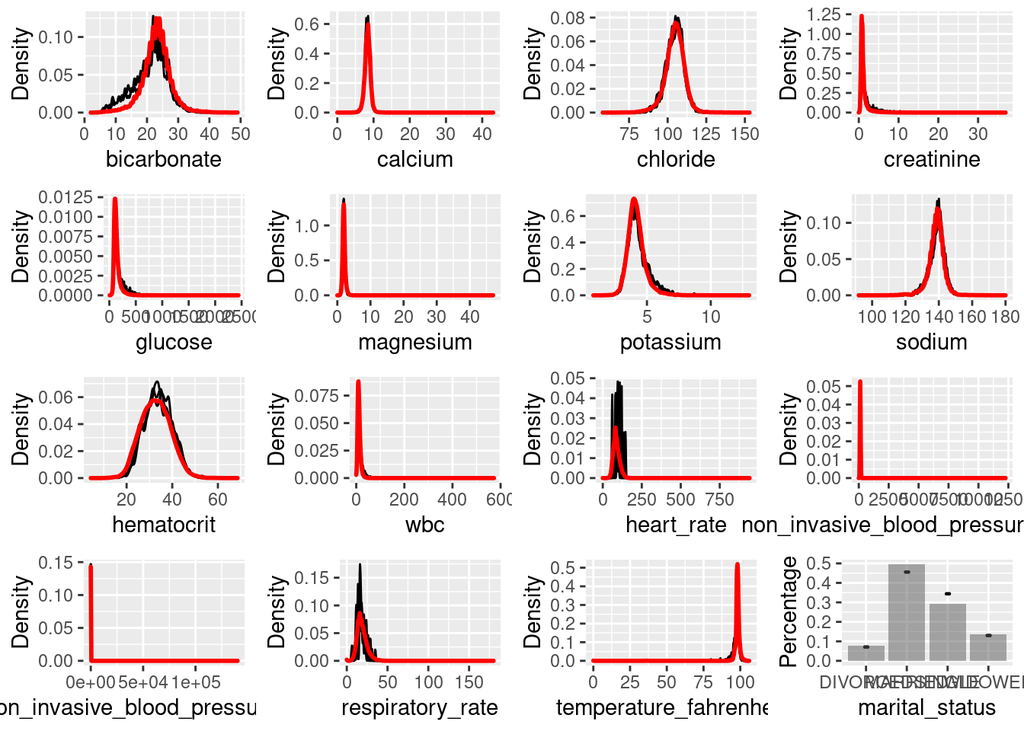

```r
plotDistributions(miceObj ,vars= c("marital_status", "bicarbonate", "calcium",
                                 "chloride", "creatinine", "glucose",
                                 "magnesium", "potassium", "sodium",
                                 "hematocrit", "wbc", "heart_rate",
                                 "non_invasive_blood_pressure_systolic",
                                 "non_invasive_blood_pressure_mean",
                                 "respiratory_rate", "temperature_fahrenheit"))
```

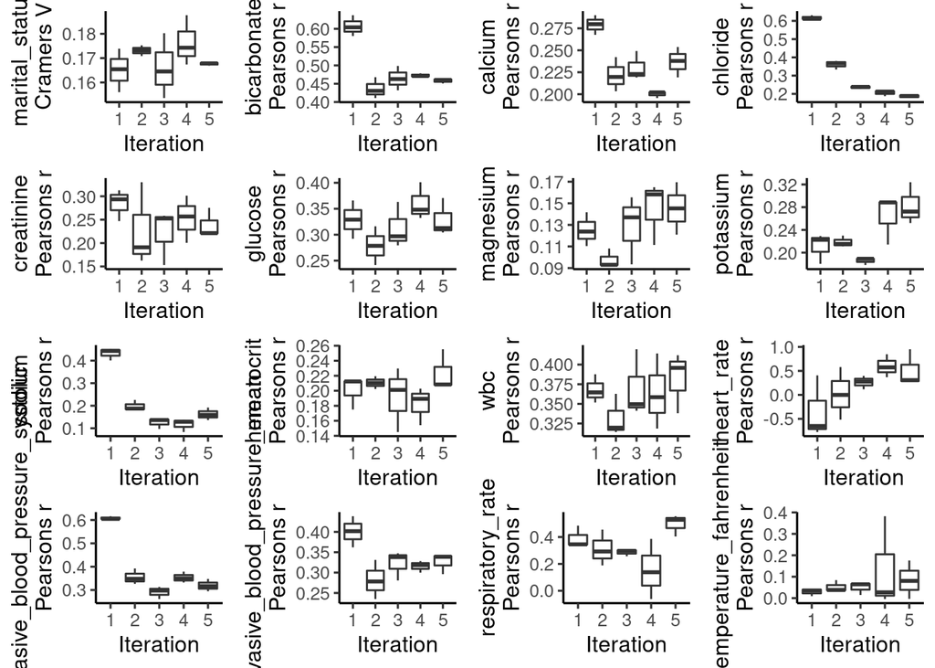

```r
plotCorrelations(miceObj,vars=c("marital_status", "bicarbonate", "calcium",
                               "chloride", "creatinine", "glucose", "magnesium",
                               "potassium", "sodium", "hematocrit", "wbc",
                               "heart_rate",
                               "non_invasive_blood_pressure_systolic",
                               "non_invasive_blood_pressure_mean",
                               "respiratory_rate", "temperature_fahrenheit"))
```

###Convergence of Correlation

The plotCorrelations function shows you a boxplot of the correlations between imputed values in every combination of datasets, at each iteration.

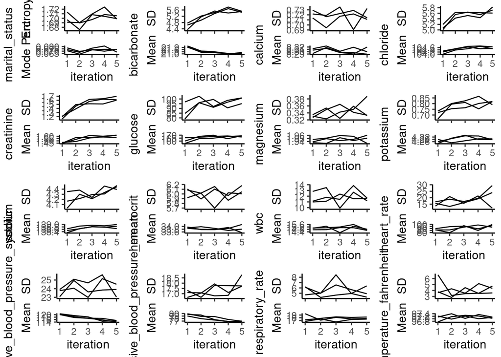

```r
plotVarConvergence(miceObj,vars=c("marital_status", "bicarbonate", "calcium",
                                 "chloride", "creatinine", "glucose",
                                 "magnesium", "potassium", "sodium",
                                 "hematocrit", "wbc", "heart_rate",
                                 "non_invasive_blood_pressure_systolic",
                                 "non_invasive_blood_pressure_mean",
                                 "respiratory_rate", "temperature_fahrenheit"))
```

###Center and Dispersion Convergence

Sometimes, if the missing data locations are correlated with higher or lower values, multiple iterations need to be run for the process to converge to the true theoretical mean (given the information that exists in the dataset). Using this plot we can see if the imputed data converged, or if we need to run more iterations.

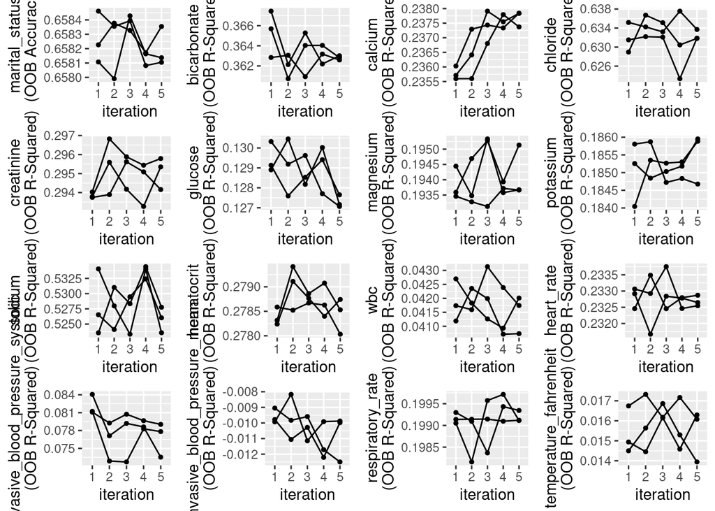

```r
plotModelError(miceObj,vars=c("marital_status", "bicarbonate", "calcium",
                             "chloride", "creatinine", "glucose", "magnesium",
                             "potassium", "sodium", "hematocrit", "wbc",
                             "heart_rate",
                             "non_invasive_blood_pressure_systolic",
                             "non_invasive_blood_pressure_mean",
                             "respiratory_rate", "temperature_fahrenheit"))
```

###Variable Importance

Below we plot the variable importance for each imputed variable. The top axis contains the variable that was used to impute the variable on the left axis.

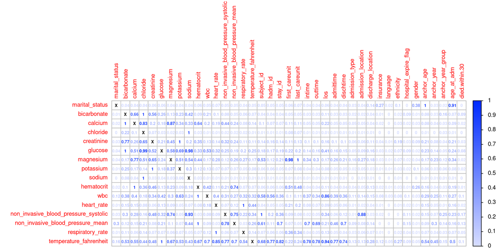

```r
plotVarImportance(miceObj,
                  tl.cex = 0.7,
                  cl.cex = 0.7, cl.ratio = 0.1, cl.align.text = "l",
                  number.cex = 0.5)
```

6. Obtain a complete data set by averaging the 3 imputed data sets.

```r
ImputedList <- completeData(miceObj)
df1 <- ImputedList$Dataset_1
df2 <- ImputedList$Dataset_2
df3 <- ImputedList$Dataset_3

#converting characters into factors, then numeric

df1 <- df1 %>% mutate_if(is.character, as.factor) %>%
  mutate_if(is.factor, as.numeric)

df2 <- df2 %>% mutate_if(is.character, as.factor) %>%
  mutate_if(is.factor, as.numeric)

df3 <- df3 %>% mutate_if(is.character, as.factor) %>%
   mutate_if(is.factor, as.numeric)


#selecting necessary columns for logistic regression (q2) before averaging
##datasets

df1 <- df1 %>% select(subject_id, gender, age_at_adm, marital_status,
                      ethnicity, bicarbonate, calcium, chloride, creatinine,
                      glucose, magnesium, potassium, sodium, hematocrit,
                      wbc, heart_rate, non_invasive_blood_pressure_systolic,
                      non_invasive_blood_pressure_mean, respiratory_rate,
                      temperature_fahrenheit, died.within.30)
df2 <- df2 %>% select(subject_id, gender, age_at_adm, marital_status,
                      ethnicity, bicarbonate, calcium, chloride, creatinine,
                      glucose, magnesium, potassium, sodium, hematocrit,
                      wbc, heart_rate, non_invasive_blood_pressure_systolic,
                      non_invasive_blood_pressure_mean, respiratory_rate,
                      temperature_fahrenheit, died.within.30)
df3 <- df3 %>% select(subject_id, gender, age_at_adm, marital_status,
                      ethnicity, bicarbonate, calcium, chloride, creatinine,
                      glucose, magnesium, potassium, sodium, hematocrit,
                      wbc, heart_rate, non_invasive_blood_pressure_systolic,
                      non_invasive_blood_pressure_mean, respiratory_rate,
                      temperature_fahrenheit, died.within.30)

#averaging datasets

av_df <- (df1 + df2 + df3)/3

av_df$marital_status <- round(av_df$marital_status)

av_df <- av_df %>% mutate_at(c("gender",
              "marital_status",
              "ethnicity"),
            function(x)as.factor(x))
```

## Q2. Predicting 30-day mortality

Develop at least two analytic approaches for predicting the 30-day mortality of patients admitted to ICU using demographic information (gender, age, marital status, ethnicity), first lab measurements during ICU stay, and first vital measurements during ICU stay. For example, you can use (1) logistic regression (`glm()` function), (2) logistic regression with lasso penalty (glmnet package), (3) random forest (randomForest package), or (4) neural network.

- Option 1: Logistic Regression
1. Partition data into 80% training set and 20% test set. Stratify partitioning according the 30-day mortality status.

```r
set.seed(203)
training_set <-av_df %>% group_by(died.within.30) %>%
  slice_sample(prop = .8)

test_set <- anti_join(av_df, training_set)
```

2. Train the models using the training set.

```r
lmod <- glm(died.within.30 ~ . -subject_id, family = binomial, training_set)
```

3. Compare model prediction performance on the test set.

```r
predprob = predict.glm(lmod, test_set, type = "response")

test_set$predout <- ifelse(predprob > 0.5, 1, 0)

xtabs(~ died.within.30 + predout , data = test_set)
```

```
##               predout
## died.within.30    0    1
##              0 8900   75
##              1  941   95
```

```r
#error rate

(75 + 939)/(8900 + 75 + 939 + 97)
```

```
## [1] 0.1012886
```

```r
#sensitivity (probability that the model correctly predicts death)

97/(939 + 97)
```

```
## [1] 0.09362934
```

```r
#specificity (probability that the model correctly predicts survival)

8900/(8900 + 75)
```

```
## [1] 0.9916435
```

The sensitivity of the model (probability that the model correctly predicts death) is 10%.

The specificity of the model (probability that the model correctly predicts survival) is 99%.

- Option 2: Logistic Regression with Lasso Penalty (glmnet package)
1. Partition data into 80% training set and 20% test set. Stratify partitioning according the 30-day mortality status.

Already done in option 1

2. Train the models using the training set.

First we fit a logistic regression with lasso penalty using the glmnet package.

```r
#The glmnet package takes a matrix (of predictors) and a vector (of responses)
##as input, so I reformatted my data

#training X and Y
x_train <- training_set %>% ungroup() %>% select(-died.within.30) %>% as.matrix()
y_train <- training_set$died.within.30

#validation/testing set

x_val <- test_set %>% ungroup() %>% select(c(-died.within.30, -predout)) %>% data.matrix()
y_val <- test_set$died.within.30

#fit lasso regression

lasso_fit <- glmnet(x_train, y_train, family = "binomial", alpha = 1)

summary(lasso_fit)
```

```
##            Length Class     Mode
## a0           58   -none-    numeric
## beta       1160   dgCMatrix S4
## df           58   -none-    numeric
## dim           2   -none-    numeric
## lambda       58   -none-    numeric
## dev.ratio    58   -none-    numeric
## nulldev       1   -none-    numeric
## npasses       1   -none-    numeric
## jerr          1   -none-    numeric
## offset        1   -none-    logical
## classnames    2   -none-    character
## call          5   -none-    call
## nobs          1   -none-    numeric
```

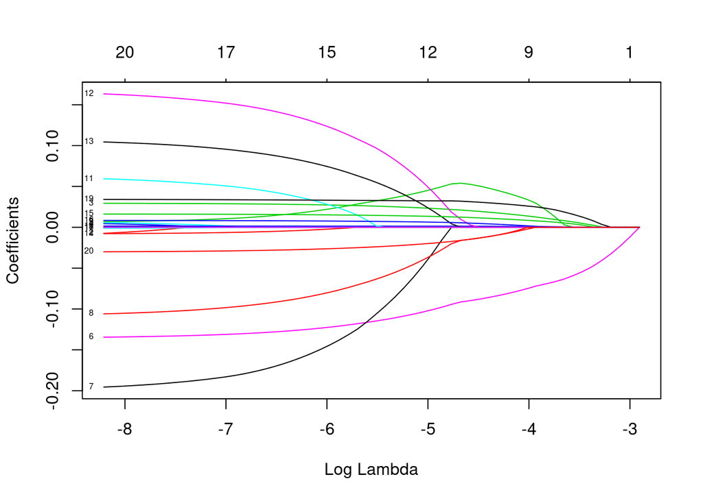

```r
plot(lasso_fit, xvar = "lambda", label = TRUE)
```

3. Compare model prediction performance on the test set.

Now we can evaluate the peformance of various models (corresponding to different $\lambda$ values on the validation set). From the graph, it appears that the lowest deviance on the validation set corresponds to the smallest value of $\lambda$, which is 0.0002707682 (~.0003).

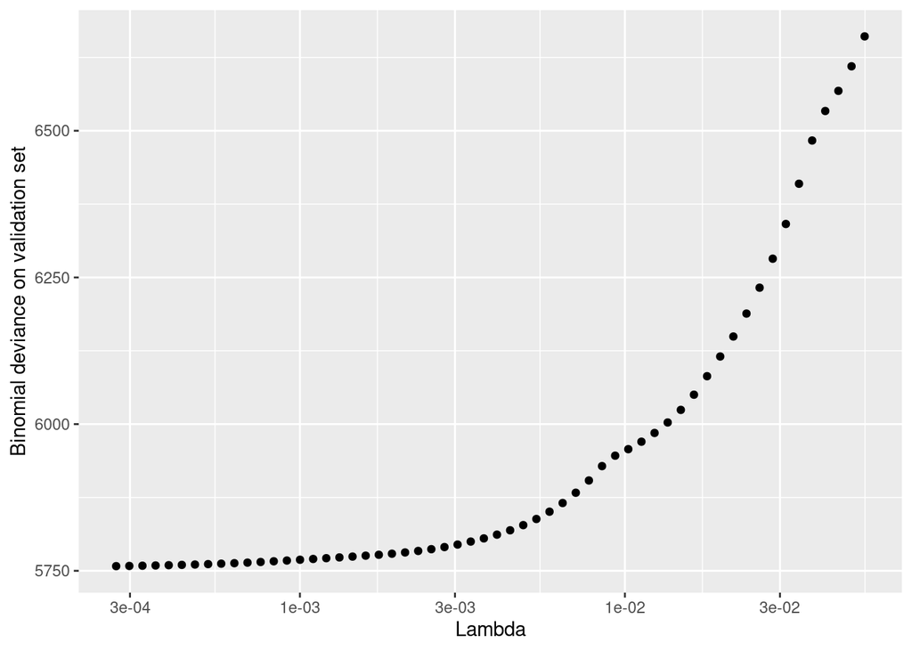

```r
# predict validation case probabilities at different \lambda values and calculate test deviance
pred_val <- predict(object = lasso_fit, newx =  as(x_val, "dgCMatrix"), type = "response", s = lasso_fit$lambda)
dev_val <- -2 * colSums(y_val * log(pred_val) + (1 - y_val) * log(1 - pred_val))
tibble(lambda = lasso_fit$lambda, dev_val = dev_val) %>%
  ggplot() +
  geom_point(mapping = aes(x = lambda, y = dev_val)) +
  scale_x_log10() +
  labs(y = "Binomial deviance on validation set", x = "Lambda")
```

```r
#min(lasso_fit$lambda)
```

Now we’ll predict the probability of 30 day mortality using the optimal value of $\lambda$ (approximately .0003) as determined above.

```r
predprob_lasso <- predict(object = lasso_fit, newx =  as(x_val, "dgCMatrix"), type = "response", s = 0.0002707682)

test_set$predout_lasso <- ifelse(predprob > 0.5, 1, 0)

xtabs(~ died.within.30 + predout_lasso , data = test_set)
```

```
##               predout_lasso
## died.within.30    0    1
##              0 8900   75
##              1  941   95
```

The sensitivity of the lasso model (probability that the model correctly predicts death) is 10%.

The specificity of the lasso model (probability that the model correctly predicts survival) is 99%.